# prr Gruppenarbeit 1

# Einleitung

Wir beschaeftigen uns mit dem Carseats Datensatz von ISRL2.

# Hypothese / Fragestellungen

1. Ist Sales abhaengig von Income/Advertising/Population der Region? (Lineare Regression)
2. Hat die Differenz von Comprice und Price einen Einfluss auf den Verkauf?
3. Ist Sales durch mehrere Features abhaengig? (Multiple Lineare Regression)
4. Werden in urbanen Regionen mehr Kindersitze gekauft? (Logistische Regression)

# Installationen

```r
library(ISLR2)
library(tidyverse)
```

# Carseats Datensatz ausgeben und beschreiben

```r
Carseats
```

|  | Sales | CompPrice | Income | Advertising | Population | Price | ShelveLoc | Age | Education | Urban | US |
| --- | --- | --- | --- | --- | --- | --- | --- | --- | --- | --- | --- |
| 1 | 9.50 | 138 | 73 | 11 | 276 | 120 | Bad | 42 | 17 | Yes | Yes |
| 2 | 11.22 | 111 | 48 | 16 | 260 | 83 | Good | 65 | 10 | Yes | Yes |
| 3 | 10.06 | 113 | 35 | 10 | 269 | 80 | Medium | 59 | 12 | Yes | Yes |
| 4 | 7.40 | 117 | 100 | 4 | 466 | 97 | Medium | 55 | 14 | Yes | Yes |
| 5 | 4.15 | 141 | 64 | 3 | 340 | 128 | Bad | 38 | 13 | Yes | No |
| 6 | 10.81 | 124 | 113 | 13 | 501 | 72 | Bad | 78 | 16 | No | Yes |
| 7 | 6.63 | 115 | 105 | 0 | 45 | 108 | Medium | 71 | 15 | Yes | No |
| 8 | 11.85 | 136 | 81 | 15 | 425 | 120 | Good | 67 | 10 | Yes | Yes |
| 9 | 6.54 | 132 | 110 | 0 | 108 | 124 | Medium | 76 | 10 | No | No |
| 10 | 4.69 | 132 | 113 | 0 | 131 | 124 | Medium | 76 | 17 | No | Yes |

[output cut: 390 more lines]

# Beschreibung des Datensatzes

Sales Unit sales (in thousands) at each location

CompPrice Price charged by competitor at each location

Income Community income level (in thousands of dollars)

Advertising Local advertising budget for company at each location (in thousands of dollars)

Population Population size in region (in thousands)

Price Price company charges for car seats at each site

ShelveLoc A factor with levels Bad, Good and Medium indicating the quality of the shelving location for the car seats at each site

Age Average age of the local population

Education Education level at each location

Urban A factor with levels No and Yes to indicate whether the store is in an urban or rural location

US A factor with levels No and Yes to indicate whether the store is in the US or not

# Kopfzeile Carseats ausgeben

```r
head(Carseats)
```

|  | Sales | CompPrice | Income | Advertising | Population | Price | ShelveLoc | Age | Education | Urban | US |
| --- | --- | --- | --- | --- | --- | --- | --- | --- | --- | --- | --- |
| 1 | 9.50 | 138 | 73 | 11 | 276 | 120 | Bad | 42 | 17 | Yes | Yes |
| 2 | 11.22 | 111 | 48 | 16 | 260 | 83 | Good | 65 | 10 | Yes | Yes |
| 3 | 10.06 | 113 | 35 | 10 | 269 | 80 | Medium | 59 | 12 | Yes | Yes |
| 4 | 7.40 | 117 | 100 | 4 | 466 | 97 | Medium | 55 | 14 | Yes | Yes |
| 5 | 4.15 | 141 | 64 | 3 | 340 | 128 | Bad | 38 | 13 | Yes | No |
| 6 | 10.81 | 124 | 113 | 13 | 501 | 72 | Bad | 78 | 16 | No | Yes |

# Endes des Datensatzes ausgeben

```r
tail(Carseats)
```

|  | Sales | CompPrice | Income | Advertising | Population | Price | ShelveLoc | Age | Education | Urban | US |
| --- | --- | --- | --- | --- | --- | --- | --- | --- | --- | --- | --- |
| 395 | 5.35 | 130 | 58 | 19 | 366 | 139 | Bad | 33 | 16 | Yes | Yes |
| 396 | 12.57 | 138 | 108 | 17 | 203 | 128 | Good | 33 | 14 | Yes | Yes |
| 397 | 6.14 | 139 | 23 | 3 | 37 | 120 | Medium | 55 | 11 | No | Yes |
| 398 | 7.41 | 162 | 26 | 12 | 368 | 159 | Medium | 40 | 18 | Yes | Yes |
| 399 | 5.94 | 100 | 79 | 7 | 284 | 95 | Bad | 50 | 12 | Yes | Yes |
| 400 | 9.71 | 134 | 37 | 0 | 27 | 120 | Good | 49 | 16 | Yes | Yes |

# Zusammenfassung von Carseats

```r
summary(Carseats)
```

```
     Sales          CompPrice       Income        Advertising       Population        Price        ShelveLoc        Age
 Min.   : 0.000   Min.   : 77   Min.   : 21.00   Min.   : 0.000   Min.   : 10.0   Min.   : 24.0   Bad   : 96   Min.   :25.00
 1st Qu.: 5.390   1st Qu.:115   1st Qu.: 42.75   1st Qu.: 0.000   1st Qu.:139.0   1st Qu.:100.0   Good  : 85   1st Qu.:39.75
 Median : 7.490   Median :125   Median : 69.00   Median : 5.000   Median :272.0   Median :117.0   Medium:219   Median :54.50
 Mean   : 7.496   Mean   :125   Mean   : 68.66   Mean   : 6.635   Mean   :264.8   Mean   :115.8                Mean   :53.32
 3rd Qu.: 9.320   3rd Qu.:135   3rd Qu.: 91.00   3rd Qu.:12.000   3rd Qu.:398.5   3rd Qu.:131.0                3rd Qu.:66.00
 Max.   :16.270   Max.   :175   Max.   :120.00   Max.   :29.000   Max.   :509.0   Max.   :191.0                Max.   :80.00
   Education    Urban       US
 Min.   :10.0   No :118   No :142
 1st Qu.:12.0   Yes:282   Yes:258
 Median :14.0
 Mean   :13.9
 3rd Qu.:16.0
 Max.   :18.0
```

# Visualisierung von Sales Verteilung (Schoener beschreiben)

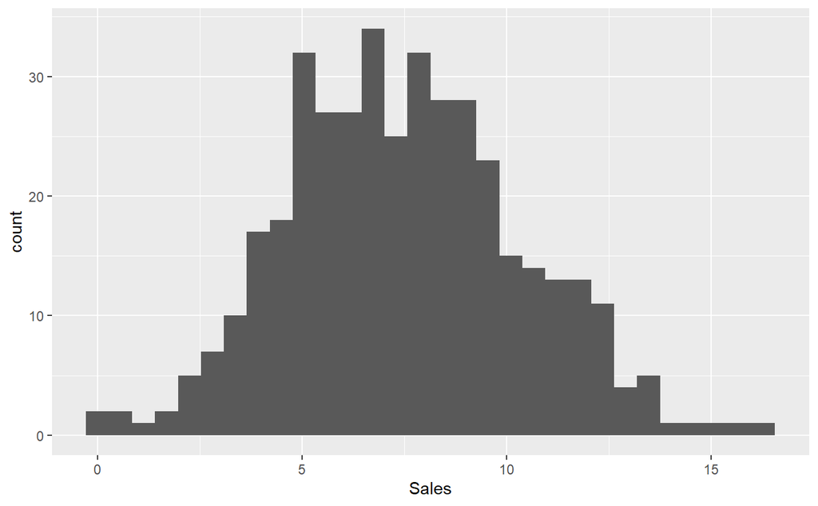

```r
ggplot(data = Carseats, aes(x = Sales)) +
  geom_histogram()
```

# Lineare Regressionsmodell

## Features in einem Scatterplot darstellen (Ausbessern!)

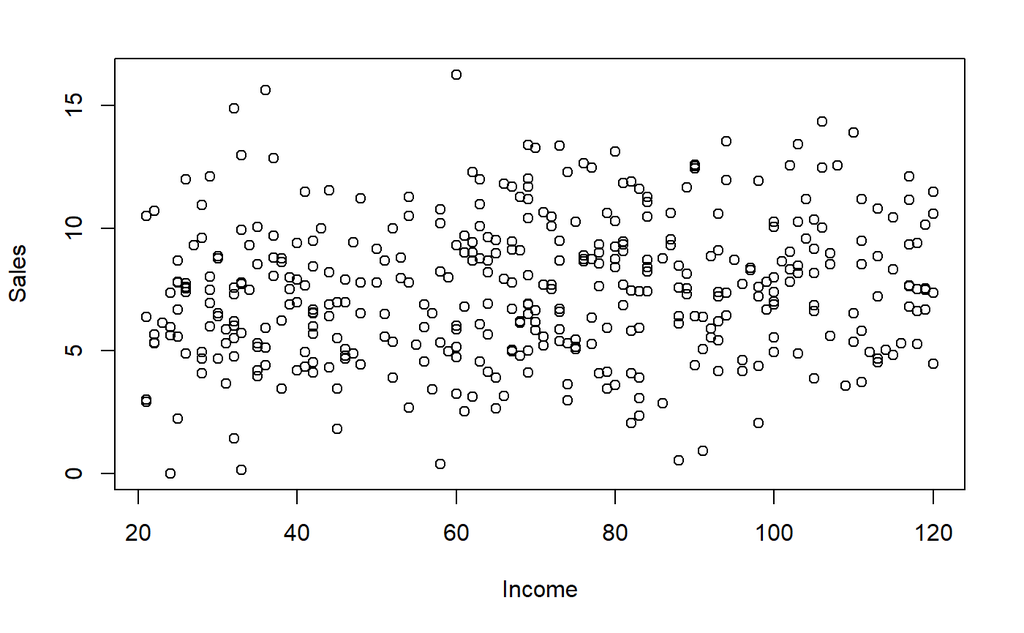

```r
plot(Sales ~ Income, data = Carseats)
```

## Modell erstellen

```r
lm.fit1 <- lm(Sales ~ Income, data = Carseats)
```

## Modell Methoden

Folgende Methoden sind nun fuer die Lineare Regression erstellt worden

```r
names(lm.fit1)
```

```
 [1] "coefficients"  "residuals"     "effects"       "rank"          "fitted.values" "assign"        "qr"
 [8] "df.residual"   "xlevels"       "call"          "terms"         "model"
```

### Koeffzienten vom Modell ausgeben

```r
lm.fit1$coefficients
```

```
(Intercept)      Income
 6.44355748  0.01533361
```

### Konfidenzintervall fuer Koeffizienten angeben

```r
confint(lm.fit1)
```

```
                  2.5 %     97.5 %
(Intercept) 5.714962797 7.17215216
Income      0.005504876 0.02516235
```

### Freiheitsgrade ausgeben ???

```r
lm.fit1$df.residual
```

```
[1] 398
```

## Auswertung vom Modell

```r
summary(lm.fit1)
```

```
Call:
lm(formula = Sales ~ Income, data = Carseats)

Residuals:
    Min      1Q  Median      3Q     Max
-7.2629 -1.9447 -0.1772  1.7654  8.9064

Coefficients:
            Estimate Std. Error t value Pr(>|t|)
(Intercept)  6.44356    0.37061  17.386  < 2e-16 ***
Income       0.01533    0.00500   3.067  0.00231 **
---
Signif. codes:  0 ‘***’ 0.001 ‘**’ 0.01 ‘*’ 0.05 ‘.’ 0.1 ‘ ’ 1

Residual standard error: 2.795 on 398 degrees of freedom
Multiple R-squared:  0.02309,   Adjusted R-squared:  0.02063
F-statistic: 9.407 on 1 and 398 DF,  p-value: 0.00231
```

Anhand vom P Wert(0.00231) laesst sich feststellen, dass die Steigung siginfikant ist. Entsprechend hat das Einkommen der Region einen Einfluss auf die Verkaufszahlen. Vor einer engueltigen Aussage muessen die Residuen ueberprueft werden.

## Visualisierung der Daten mit dem Regressions Modell (Visualsierung ausbessern)

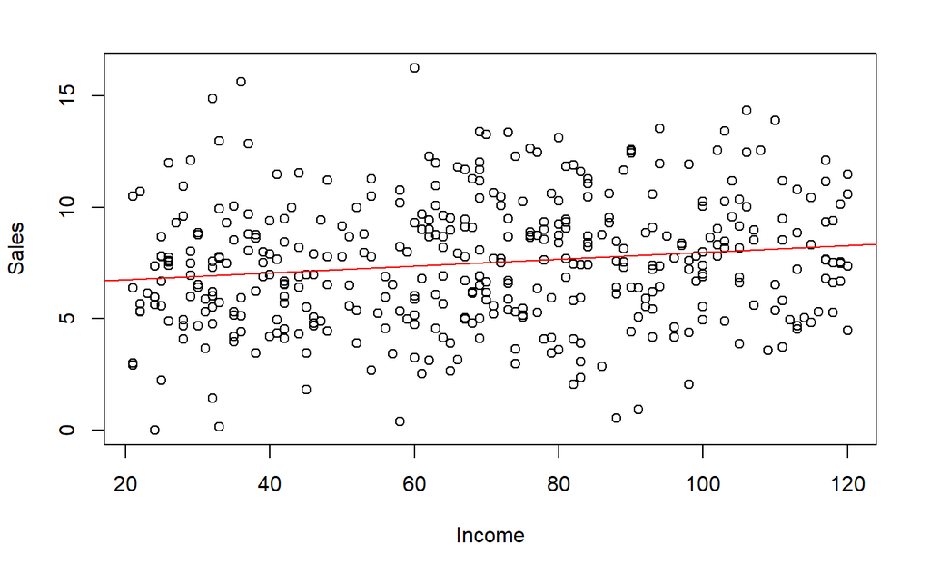

```r
plot(Sales ~ Income, data = Carseats)
abline(lm.fit1, col = "red")
```

## Residuenanalyse (Visualisierung ausbessern)

Nun, da wir unser Modell haben, können wir feststellen, ob es ein gutes Modell ist, indem wir diese 3 Bedingungen überprüfen:

Der Fehler sollte nicht abhängig sein Der Erwartungswert sollte bei 0 liegen. Die Residuen sollten einer Normalverteilung folgen

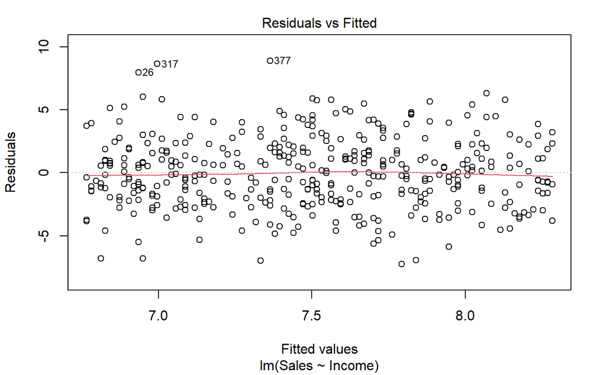

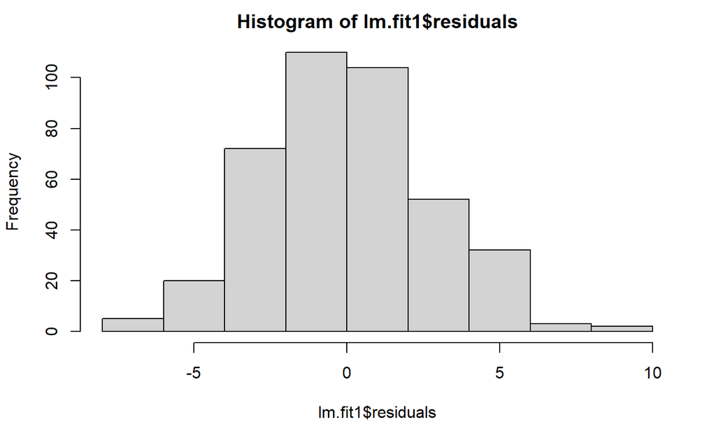

Mittelwert der Residuen ist 0. Die Verteilung ist einigermassen Normalverteilt.

## Sales vs. Population

```r
lm.fit2 <- lm(Sales ~ Population, data = Carseats)
summary(lm.fit2)
```

```
Call:
lm(formula = Sales ~ Population, data = Carseats)

Residuals:
    Min      1Q  Median      3Q     Max
-7.5864 -2.0176 -0.0597  1.6892  8.7213

Coefficients:
             Estimate Std. Error t value Pr(>|t|)
(Intercept) 7.2401837  0.2906658  24.909   <2e-16 ***
Population  0.0009672  0.0009593   1.008    0.314
---
Signif. codes:  0 ‘***’ 0.001 ‘**’ 0.01 ‘*’ 0.05 ‘.’ 0.1 ‘ ’ 1

Residual standard error: 2.824 on 398 degrees of freedom
Multiple R-squared:  0.002547,  Adjusted R-squared:  4.116e-05
F-statistic: 1.016 on 1 and 398 DF,  p-value: 0.314
```

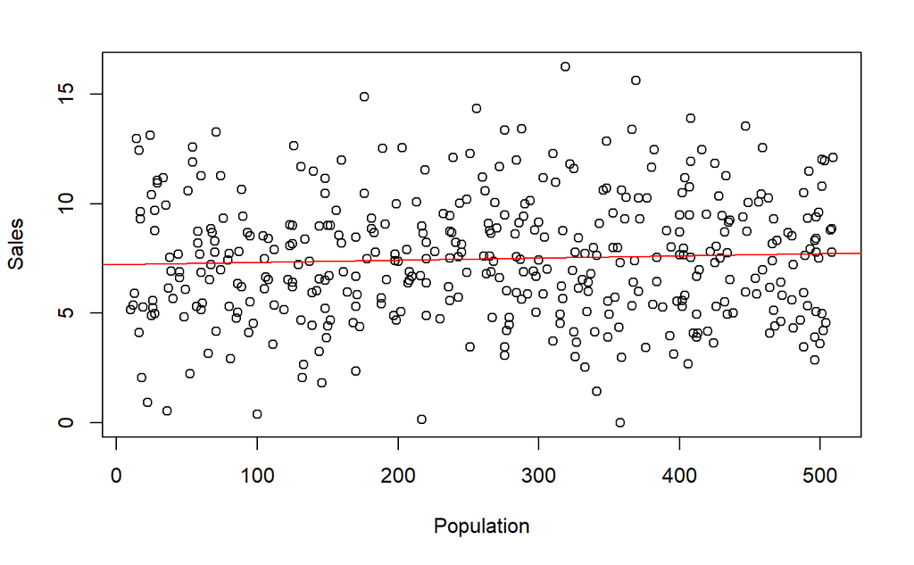

```r
plot(Sales ~ Population, data = Carseats)
abline(lm.fit2, col = "red")
```

## Sales vs. Advertising

```r
lm.fit3 <- lm(Sales ~ Advertising, data = Carseats)
summary(lm.fit3)
```

```
Call:
lm(formula = Sales ~ Advertising, data = Carseats)

Residuals:
    Min      1Q  Median      3Q     Max
-7.3770 -1.9634 -0.1037  1.7222  8.3208

Coefficients:
            Estimate Std. Error t value Pr(>|t|)
(Intercept)   6.7370     0.1925  35.007  < 2e-16 ***
Advertising   0.1144     0.0205   5.583 4.38e-08 ***
---
Signif. codes:  0 ‘***’ 0.001 ‘**’ 0.01 ‘*’ 0.05 ‘.’ 0.1 ‘ ’ 1

Residual standard error: 2.723 on 398 degrees of freedom
Multiple R-squared:  0.07263,   Adjusted R-squared:  0.0703
F-statistic: 31.17 on 1 and 398 DF,  p-value: 4.378e-08
```

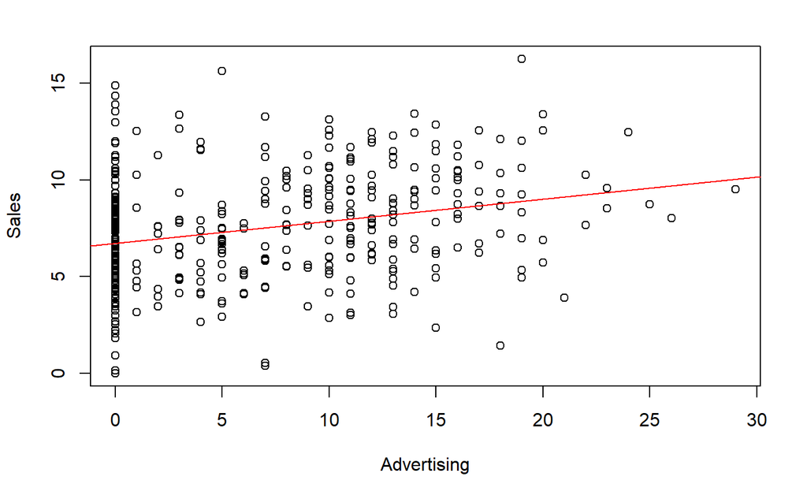

```r
plot(Sales ~ Advertising, data = Carseats)
abline(lm.fit3, col = "red")
```

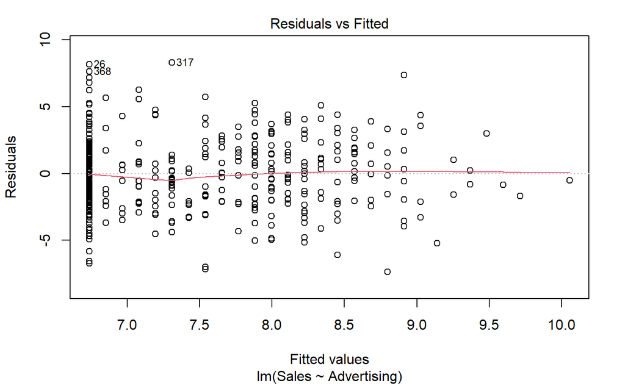

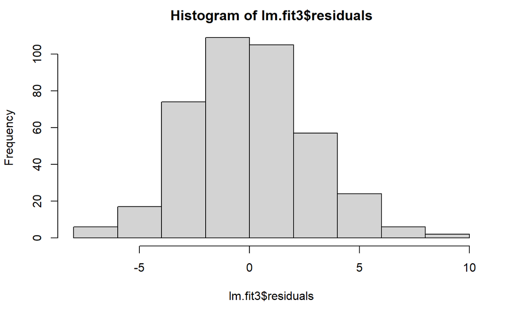

# Multiple lineare Regressionsmodell